# chapter5

Maika

21 helmikuuta 2017

# Dimensionality reduction

*This week we aim to reduce dimensions in order to notice better the relations between variables in the data*

## 1. Principal component analysis

```r
#Packages we need in this workout
library(GGally)
library(dplyr)
```

```r
library(corrplot)
library(FactoMineR)
library(ggplot2)
library(tidyr)
```

First part of our dimensionality reduction conserns with continuous variables. Dimensionality reduction in general aims to find the most essential dimensions that explain the data. In Principal Componen Analysis (PCA), we try to find the most essential components (usually PC1 and PC2) that best explain the data.

### 1.1 Our data

This dataset originates from United Nations Development Programme(http://hdr.undp.org/en/content/human-development-index-hdi). Its goal is to compare nations with more sophisticated methods than just looking at GNP - through human capabilities.

*Variables*

I have created a subset called “human” with 8 variables and 155 observations. Variables modified from original dataset are Country, sex_edu2, Lab_ratio and GNI. For further information about modifications made, you can go and check my github repository: https://github.com/macabset/IODS-project/blob/master/data/create_human.R

Underneath are the names of the 8 variables and their description.

Country: used as rownames, regions not included

- Sex_edu2: ratio of females to males in at least secondary education
- Lab-ratio: ratio of female labour force to male labour force
- Edu_expect: Expected years of education
- Life_expect: Life expectancy at birth
- GNI: Gross National Income per capita
- Mom_death: Maternal mortality ratio
- Young_birth: Adolescent birth rate
- Present_parl: Percentage of female representatives in parliament

*Observations*

In addition I have excluded missing values from our data set by removing them.

```r
getwd()
```

```
## [1] "C:/Users/Petri/Documents/GitHub/IODS-project"
```

```r
human <- read.csv("data/human.csv", sep=",", header= T, row.names = 1)
str(human)
```

```
## 'data.frame':    155 obs. of  8 variables:
##  $ Sex_edu2    : num  1.007 0.997 0.983 0.989 0.969 ...
##  $ Lab_ratio   : num  0.891 0.819 0.825 0.884 0.829 ...
##  $ Edu_expect  : num  17.5 20.2 15.8 18.7 17.9 16.5 18.6 16.5 15.9 19.2 ...
##  $ Life_expect : num  81.6 82.4 83 80.2 81.6 80.9 80.9 79.1 82 81.8 ...
##  $ GNI         : int  166 135 156 139 140 137 127 154 134 117 ...
##  $ Mom_death   : int  4 6 6 5 6 7 9 28 11 8 ...
##  $ Young_birth : num  7.8 12.1 1.9 5.1 6.2 3.8 8.2 31 14.5 25.3 ...
##  $ Present_parl: num  39.6 30.5 28.5 38 36.9 36.9 19.9 19.4 28.2 31.4 ...
```

```r
dim(human)
```

```
## [1] 155   8
```

```r
head(human)
```

```
##              Sex_edu2 Lab_ratio Edu_expect Life_expect GNI Mom_death
## Norway      1.0072389 0.8908297       17.5        81.6 166         4
## Australia   0.9968288 0.8189415       20.2        82.4 135         6
## Switzerland 0.9834369 0.8251001       15.8        83.0 156         6
## Denmark     0.9886128 0.8840361       18.7        80.2 139         5
## Netherlands 0.9690608 0.8286119       17.9        81.6 140         6
## Germany     0.9927835 0.8072289       16.5        80.9 137         7
##             Young_birth Present_parl
## Norway              7.8         39.6
## Australia          12.1         30.5
## Switzerland         1.9         28.5
## Denmark             5.1         38.0
## Netherlands         6.2         36.9
## Germany             3.8         36.9
```

*Summaries*

```r
summary(human)
```

```
##     Sex_edu2        Lab_ratio        Edu_expect     Life_expect
##  Min.   :0.1717   Min.   :0.1857   Min.   : 5.40   Min.   :49.00
##  1st Qu.:0.7264   1st Qu.:0.5984   1st Qu.:11.25   1st Qu.:66.30
##  Median :0.9375   Median :0.7535   Median :13.50   Median :74.20
##  Mean   :0.8529   Mean   :0.7074   Mean   :13.18   Mean   :71.65
##  3rd Qu.:0.9968   3rd Qu.:0.8535   3rd Qu.:15.20   3rd Qu.:77.25
##  Max.   :1.4967   Max.   :1.0380   Max.   :20.20   Max.   :83.50
##       GNI           Mom_death       Young_birth      Present_parl
##  Min.   :  2.00   Min.   :   1.0   Min.   :  0.60   Min.   : 0.00
##  1st Qu.: 53.50   1st Qu.:  11.5   1st Qu.: 12.65   1st Qu.:12.40
##  Median : 99.00   Median :  49.0   Median : 33.60   Median :19.30
##  Mean   : 98.73   Mean   : 149.1   Mean   : 47.16   Mean   :20.91
##  3rd Qu.:143.50   3rd Qu.: 190.0   3rd Qu.: 71.95   3rd Qu.:27.95
##  Max.   :194.00   Max.   :1100.0   Max.   :204.80   Max.   :57.50
```

All our variables are numeric and continuous, which is as hoped for PCA analysis. But before we jump to analyzing with PCA, let’slook what we can say at this stage.

### 1.2 Picturing human

```r
cor(human)
```

```
##                  Sex_edu2    Lab_ratio  Edu_expect Life_expect
## Sex_edu2      1.000000000  0.009564039  0.59325156   0.5760299
## Lab_ratio     0.009564039  1.000000000  0.04732183  -0.1400125
## Edu_expect    0.593251562  0.047321827  1.00000000   0.7894392
## Life_expect   0.576029853 -0.140012504  0.78943917   1.0000000
## GNI           0.177158634 -0.012970053  0.12134933   0.1928623
## Mom_death    -0.660931770  0.240461075 -0.73570257  -0.8571684
## Young_birth  -0.529418415  0.120158862 -0.70356489  -0.7291774
## Present_parl  0.078635285  0.250232608  0.20608156   0.1700863
##                       GNI  Mom_death Young_birth Present_parl
## Sex_edu2      0.177158634 -0.6609318  -0.5294184  0.078635285
## Lab_ratio    -0.012970053  0.2404611   0.1201589  0.250232608
## Edu_expect    0.121349332 -0.7357026  -0.7035649  0.206081561
## Life_expect   0.192862316 -0.8571684  -0.7291774  0.170086312
## GNI           1.000000000 -0.1001664  -0.1334416  0.002672262
## Mom_death    -0.100166367  1.0000000   0.7586615 -0.089439999
## Young_birth  -0.133441591  0.7586615   1.0000000 -0.070878096
## Present_parl  0.002672262 -0.0894400  -0.0708781  1.000000000
```

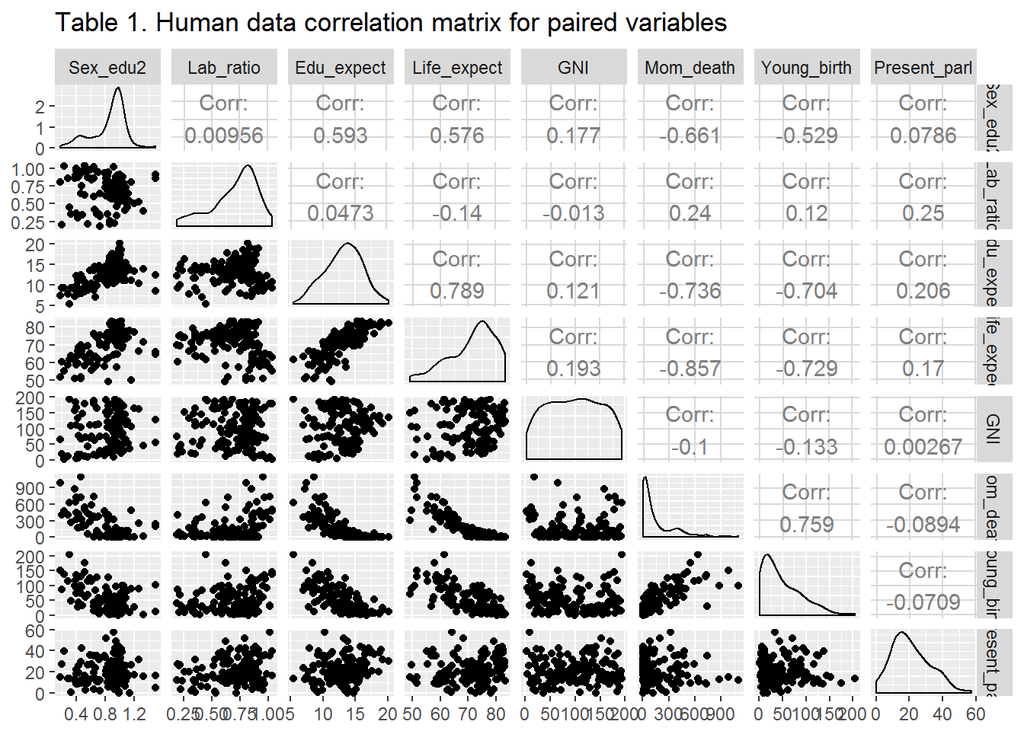

```r
ggpairs(human, title = "Table 1. Human data correlation matrix for paired variables")
```

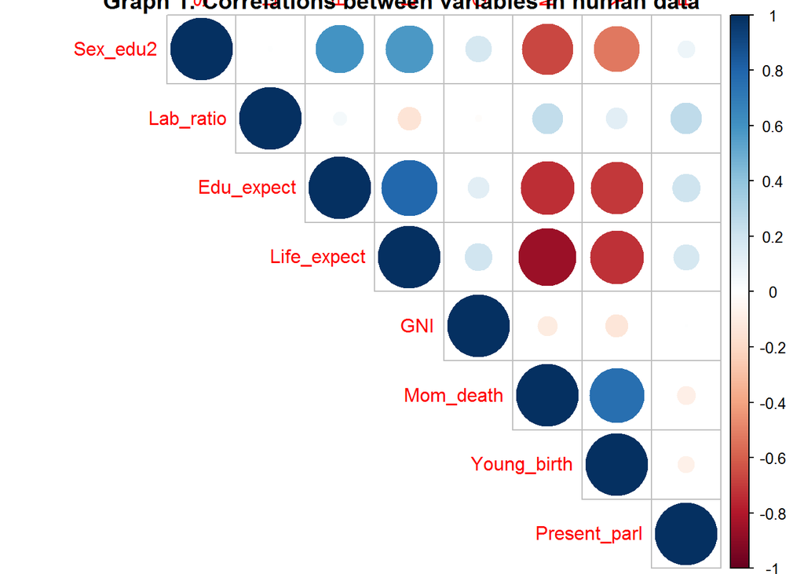

```r
cor(human) %>% corrplot( method="circle", type="upper", title= "Graph 1. Correlations between variables in human data")
```

- Whith these preliminary results can be assumed that
- 1. the higher the mothers’ mortal rate is the lower the life expectancies at birth.
- 2. the higher the mothers’ mortal rate is the lower the expected education levels
- 3. the more there are adolescent births the lower the life expectancy at birth.
- 4. and the more there are young people giving births the lower the expected level of education.

All in all, this suggests that if we want our human capacity to be used well, we need to take care of the mothers and allow family planning at young age.

### Principal component analysis

In Principal Component Analysis(PCA), variables are reduced to 2 main components that describe the data. With this method we are able to make our 8-dimensional dataset to 2D dataset when picturing it. At the same time the original variables are left and their relations to principal components can be evaluated.

*PCA*

```r
pca_human <- prcomp(human)
pca_human
```

```
## Standard deviations:
## [1] 214.3202186  54.4858892  26.3814123  11.4791149   4.0668732   1.6067062
## [7]   0.1905111   0.1586732
##
## Rotation:
##                        PC1           PC2           PC3           PC4
## Sex_edu2     -0.0007468424  4.707363e-04 -0.0001689810 -0.0004252438
## Lab_ratio     0.0002210928  5.783875e-05 -0.0007563442 -0.0047679411
## Edu_expect   -0.0098109042  2.441895e-03 -0.0223269972 -0.0369246053
## Life_expect  -0.0334485095  1.573401e-02 -0.0303860782 -0.0780112042
## GNI          -0.0278166075  9.979413e-01  0.0557767706 -0.0002740466
## Mom_death     0.9879825869  3.620190e-02 -0.1474236772 -0.0068326906
## Young_birth   0.1479114018 -5.046353e-02  0.9867754042 -0.0069374879
## Present_parl -0.0048164618 -1.494485e-03 -0.0026652825 -0.9962093264
##                        PC5           PC6           PC7           PC8
## Sex_edu2      0.0002964017 -0.0254740423  6.859097e-01  7.272399e-01
## Lab_ratio    -0.0034895150 -0.0320024527  7.265303e-01 -6.863629e-01
## Edu_expect   -0.1947276781 -0.9790080609 -4.054956e-02  3.992920e-03
## Life_expect  -0.9759219723  0.1979058277  5.461806e-03  2.081465e-03
## GNI           0.0150268685 -0.0014692010 -3.631899e-04 -3.767644e-04
## Mom_death    -0.0282554922 -0.0005722709  1.213189e-04  8.299757e-04
## Young_birth  -0.0393039689 -0.0160315111 -4.359137e-05 -9.463203e-05
## Present_parl  0.0841200882  0.0210694313 -2.695182e-03  2.658636e-03
```

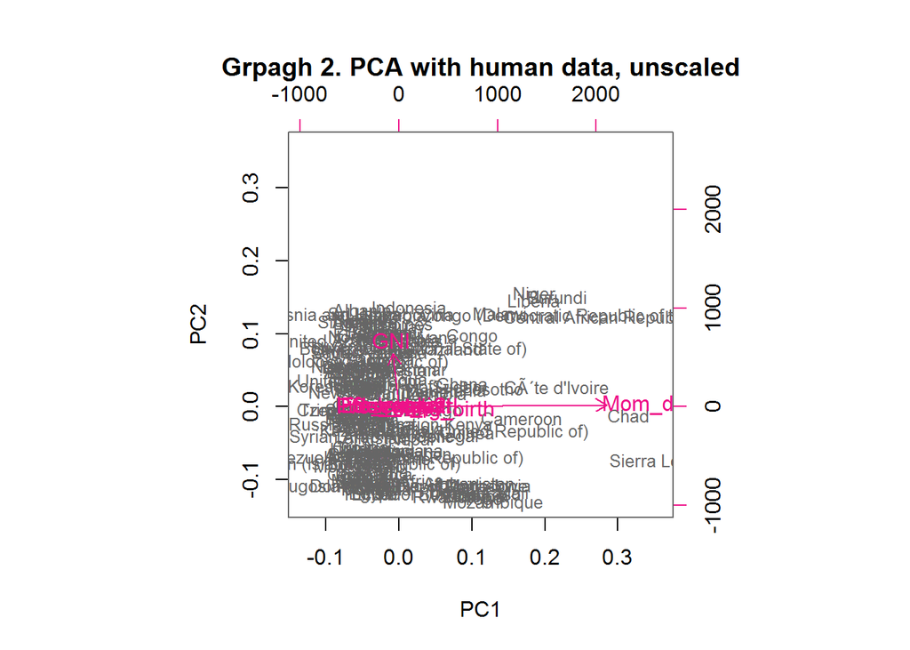

```r
biplot(pca_human, choices = 1:2, cex = c(0.8, 1), col= c("grey40", "deeppink2"), main = "Grpagh 2. PCA with human data, unscaled")
```

First I have made the PCA and biplotted it without scaling the data. In our biplot we see observations on grey and correlation arrows on pink. How observations and arrows situate in our plot is defined by the principal components PC1 and PC2. The arrows combine both the original data and its features to the principal components.

Here the variables are not measured in the same units. We have to scale them in order to give the same influence to each one. And now let’s do it properly with standardized variables.

*Scaled PCA*

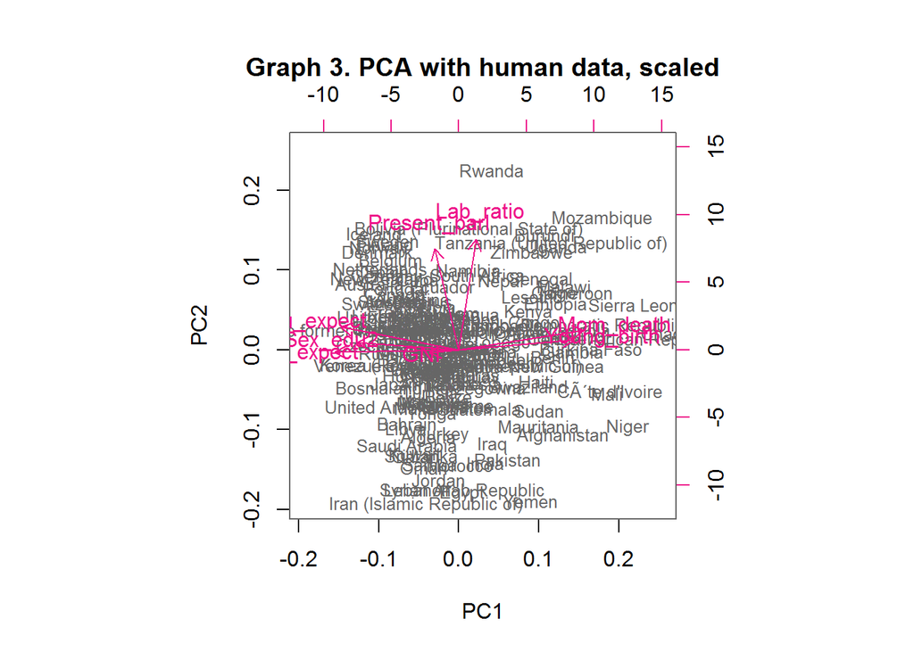

```r
human.std <- scale(human)
pca_human2 <- prcomp(human.std)
biplot(pca_human2, choices= 1:2, cex = c(0.8, 1), col= c("grey40", "deeppink2"), main="Graph 3. PCA with human data, scaled")
```

If we compare the scaled and the unscaled one, we clearly see that the correlation arrows look quite different. Scaled version is better so, that our variables are comparable.

Next, we want to modify our plot, so the percentages of the variance by the principal components can be seen. PCA expects that the more variance the better the PC.

*Scaled and modified PCA*

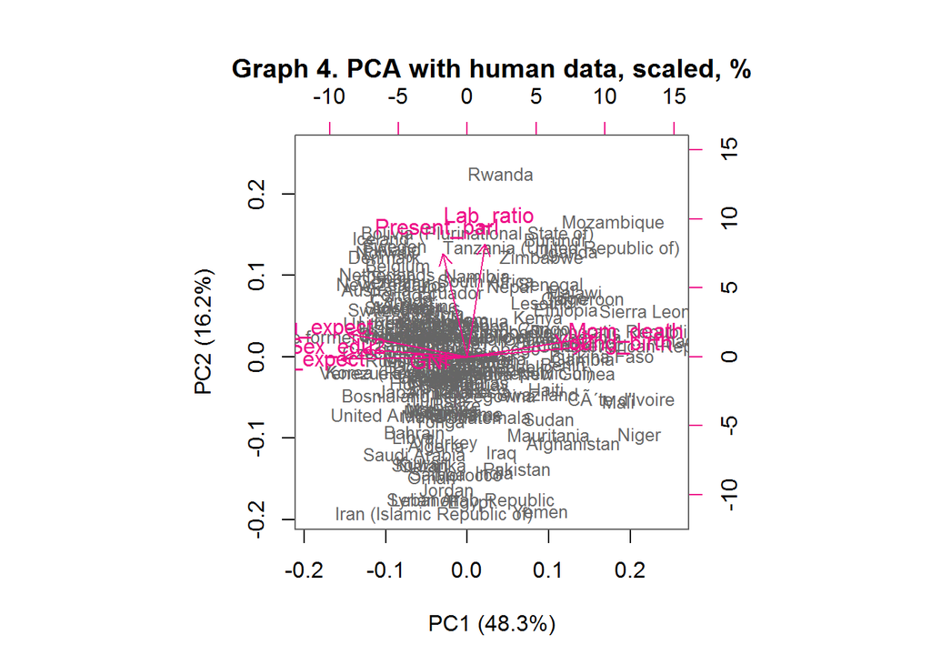

```r
s <- summary(pca_human2)
pca_pr <- round(100*s$importance[2, ], digits = 1)

# create object pc_lab to be used as axis labels
pc_lab <- paste0(names(pca_pr), " (", pca_pr, "%)")

# draw a biplot
biplot(pca_human2, cex = c(0.8, 1), col = c("grey40", "deeppink2"), xlab = pc_lab[1], ylab = pc_lab[2], main="Graph 4. PCA with human data, scaled, %")
```

And underneath we have a graph from the same scaled PCA with correlations arrows showing in a different graph than observations, since they are a bit hard to see in the original picture.

*Scaled PCA with correlation arrows*

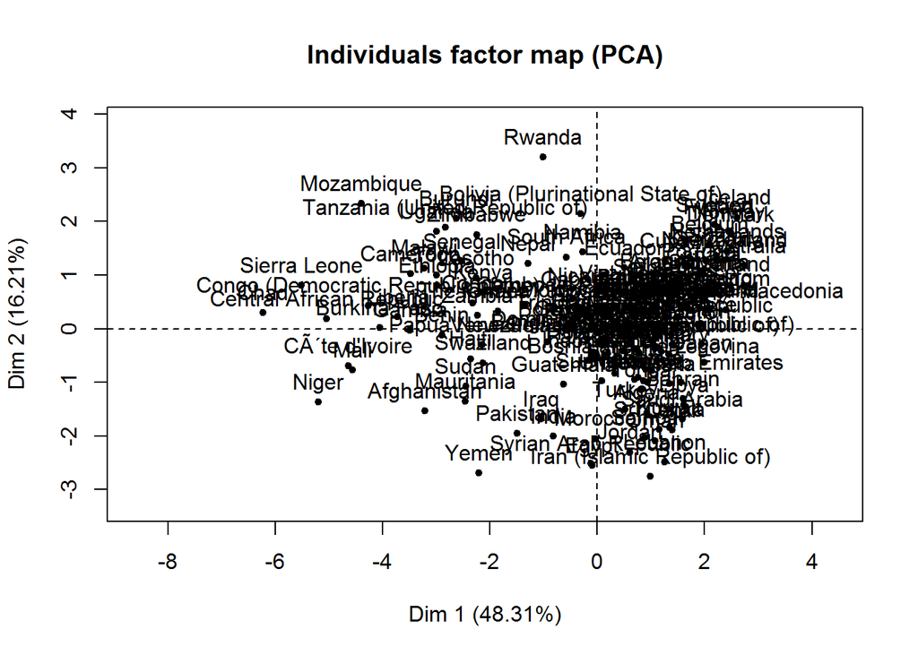

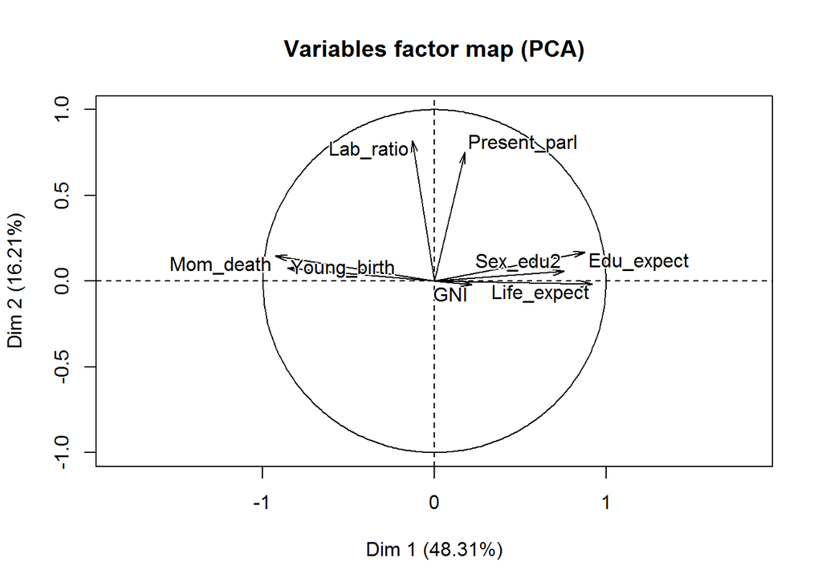

```r
#Draw a pca with only arrows

es.pca = PCA(human, scale.unit= TRUE, ncp=5)
```

The two Principal components together resume 64% of all variance of the dataset.

The more mothers die the more young people give birth to children. This on the other hand is negatively correlated to PC1: the more mothers die and young people give birth to children, the worse the state of nation is.

The correlation between ratio of women to men working and women present in parliamen is visible but not as strong as previous connections. Nevertheless, the more women at labour markets, the better presentation they have in the parliament. These are positively correlated to PC2, which means that the better women are represented at the labour markets and at the parliament, the better state the nation has.

## 2. Multiple Correspondence Analysis

Our goal is to find out if groups are close or far from each other. The closer the variables are to each other the more the same people have answered to both categories.Also, the higher numbers in the x or y axis, the stronger the correlation to dimensions it corresponds to.

### Data - Tea time!

The next part of reducing dimensions happens with R’s own dataset “Tea”. It’s a questionnaire about how people drink tea and about their drinking habbits. For more information, you can check for website:http://factominer.free.fr/classical-methods/multiple-correspondence-analysis.html.

The data set has 300 observations and 36 variables. In the data we have either factor variables with varying levels or logical variables such as “sugar” or “no sugar”, albeit age which is here both categorical and continuous.

```r
#ggplot2, dplyr, tidyr and FactoMineR available
data(tea)
my_tea <- data.frame(tea)
dim(my_tea)
```

```
## [1] 300  36
```

```r
str(my_tea)
```

```
## 'data.frame':    300 obs. of  36 variables:
##  $ breakfast       : Factor w/ 2 levels "breakfast","Not.breakfast": 1 1 2 2 1 2 1 2 1 1 ...
##  $ tea.time        : Factor w/ 2 levels "Not.tea time",..: 1 1 2 1 1 1 2 2 2 1 ...
##  $ evening         : Factor w/ 2 levels "evening","Not.evening": 2 2 1 2 1 2 2 1 2 1 ...
##  $ lunch           : Factor w/ 2 levels "lunch","Not.lunch": 2 2 2 2 2 2 2 2 2 2 ...
##  $ dinner          : Factor w/ 2 levels "dinner","Not.dinner": 2 2 1 1 2 1 2 2 2 2 ...
##  $ always          : Factor w/ 2 levels "always","Not.always": 2 2 2 2 1 2 2 2 2 2 ...
##  $ home            : Factor w/ 2 levels "home","Not.home": 1 1 1 1 1 1 1 1 1 1 ...
##  $ work            : Factor w/ 2 levels "Not.work","work": 1 1 2 1 1 1 1 1 1 1 ...
##  $ tearoom         : Factor w/ 2 levels "Not.tearoom",..: 1 1 1 1 1 1 1 1 1 2 ...
##  $ friends         : Factor w/ 2 levels "friends","Not.friends": 2 2 1 2 2 2 1 2 2 2 ...
##  $ resto           : Factor w/ 2 levels "Not.resto","resto": 1 1 2 1 1 1 1 1 1 1 ...
##  $ pub             : Factor w/ 2 levels "Not.pub","pub": 1 1 1 1 1 1 1 1 1 1 ...
##  $ Tea             : Factor w/ 3 levels "black","Earl Grey",..: 1 1 2 2 2 2 2 1 2 1 ...
##  $ How             : Factor w/ 4 levels "alone","lemon",..: 1 3 1 1 1 1 1 3 3 1 ...
```

[output cut: 22 more lines]

```r
summary(my_tea)
```

```
##          breakfast           tea.time          evening          lunch
##  breakfast    :144   Not.tea time:131   evening    :103   lunch    : 44
##  Not.breakfast:156   tea time    :169   Not.evening:197   Not.lunch:256
##
##
##
##
##
##         dinner           always          home           work
##  dinner    : 21   always    :103   home    :291   Not.work:213
##  Not.dinner:279   Not.always:197   Not.home:  9   work    : 87
##
##
##
##
##
##         tearoom           friends          resto          pub
##  Not.tearoom:242   friends    :196   Not.resto:221   Not.pub:237
##  tearoom    : 58   Not.friends:104   resto    : 79   pub    : 63
##
##
##
##
##
##         Tea         How           sugar                     how
##  black    : 74   alone:195   No.sugar:155   tea bag           :170
##  Earl Grey:193   lemon: 33   sugar   :145   tea bag+unpackaged: 94
##  green    : 33   milk : 63                  unpackaged        : 36
##                  other:  9
##
##
##
##                   where                 price          age        sex
##  chain store         :192   p_branded      : 95   Min.   :15.00   F:178
##  chain store+tea shop: 78   p_cheap        :  7   1st Qu.:23.00   M:122
##  tea shop            : 30   p_private label: 21   Median :32.00
##                             p_unknown      : 12   Mean   :37.05
##                             p_upscale      : 53   3rd Qu.:48.00
##                             p_variable     :112   Max.   :90.00
##
```

[output cut: 25 more lines]

```
##  feminine    :129   Not.sophisticated: 85   No.slimming:255
##  Not.feminine:171   sophisticated    :215   slimming   : 45
##
##
##
##
##
##         exciting          relaxing              effect.on.health
##  exciting   :116   No.relaxing:113   effect on health   : 66
##  No.exciting:184   relaxing   :187   No.effect on health:234
##
##
##
##
##
```

To find ou which might be the most interesting variables, let’s make some pictures!

*Picuring the tea data*

Bar plot

[figure not shown]

```r
gather(my_tea) %>% ggplot(aes(value))  + facet_wrap("key", scales = "free") + geom_bar() + theme(axis.text.x = element_text(angle = 45, hjust = 1, size = 8))
```

for the sake of simplicity. I’ll pick a sub dataset my_tea1 with 8 variables breakfast, sex, price, health, spirituality, tearoom, Tea and friends.

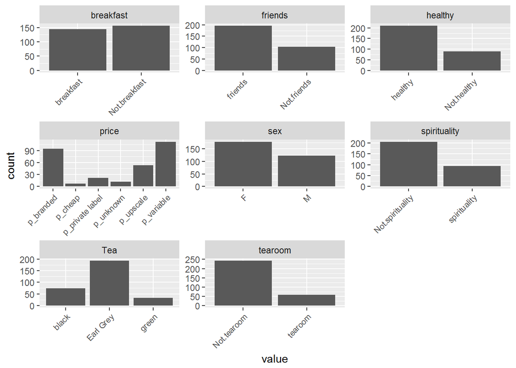

```r
#Columns for our subset my_tea1
keep_columns <- c("breakfast", "sex", "price", "healthy", "spirituality", "friends", "Tea", "tearoom")
my_tea1 <- dplyr::select(my_tea, one_of(keep_columns))
#Picturing with bars
gather(my_tea1) %>% ggplot(aes(value)) + facet_wrap("key", scales = "free") + geom_bar() + theme(axis.text.x = element_text(angle = 45, hjust = 1, size = 8))
```

### Multiple Correspondence Analysis

The idea is to find out whether these groups have anything incommon with each other. MCA examines the links between variables based on the variance of the observations. Does spirituality accure with expencive tea? Does gender have anything to do with assumptions whether tea is healthy or not? Now, we’re ready to do our MCA with our my_tea1.

*MCA graph 1*

```r
mca <- MCA(my_tea1, graph = FALSE)

# summary of the model
summary(mca)
```

```
##
## Call:
## MCA(X = my_tea1, graph = FALSE)
##
##
## Eigenvalues
##                        Dim.1   Dim.2   Dim.3   Dim.4   Dim.5   Dim.6
## Variance               0.193   0.165   0.150   0.147   0.139   0.128
## % of var.             11.885  10.164   9.218   9.031   8.544   7.859
## Cumulative % of var.  11.885  22.050  31.268  40.299  48.843  56.702
##                        Dim.7   Dim.8   Dim.9  Dim.10  Dim.11  Dim.12
## Variance               0.121   0.115   0.110   0.102   0.096   0.087
## % of var.              7.429   7.054   6.784   6.297   5.928   5.371
## Cumulative % of var.  64.131  71.185  77.970  84.267  90.195  95.565
##                       Dim.13
## Variance               0.072
## % of var.              4.435
## Cumulative % of var. 100.000
##
## Individuals (the 10 first)
##                    Dim.1    ctr   cos2    Dim.2    ctr   cos2    Dim.3
## 1               |  0.767  1.015  0.144 |  0.347  0.242  0.029 |  0.713
## 2               |  0.261  0.117  0.057 |  0.285  0.164  0.069 | -0.327
## 3               | -0.400  0.276  0.233 | -0.236  0.113  0.081 |  0.005
## 4               |  0.057  0.006  0.003 | -0.199  0.080  0.034 |  0.209
## 5               | -0.005  0.000  0.000 |  0.067  0.009  0.003 |  0.484
## 6               |  0.641  0.709  0.171 | -0.080  0.013  0.003 |  0.234
## 7               | -0.151  0.039  0.028 |  0.019  0.001  0.000 |  0.020
## 8               |  0.262  0.118  0.059 |  0.161  0.052  0.022 | -0.149
## 9               |  0.533  0.491  0.180 |  0.465  0.437  0.137 |  0.375
## 10              |  0.503  0.436  0.118 |  1.130  2.577  0.594 | -0.477
##                    ctr   cos2
## 1                1.132  0.125 |
## 2                0.238  0.090 |
## 3                0.000  0.000 |
## 4                0.097  0.037 |
## 5                0.521  0.164 |
## 6                0.122  0.023 |
## 7                0.001  0.001 |
## 8                0.050  0.019 |
```

[output cut: 22 more lines]

```
## p_private label   0.006   1.301 |   0.150   0.131   0.002   0.709 |
## p_unknown         0.000  -0.142 |   2.649  23.430   0.292   9.351 |
## p_upscale         0.300   9.475 |  -0.267   1.049   0.015  -2.137 |
## p_variable        0.021   2.493 |   0.024   0.019   0.000   0.326 |
##
## Categorical variables (eta2)
##                   Dim.1 Dim.2 Dim.3
## breakfast       | 0.000 0.041 0.075 |
## sex             | 0.186 0.044 0.086 |
## price           | 0.319 0.560 0.369 |
## healthy         | 0.010 0.044 0.413 |
## spirituality    | 0.082 0.019 0.000 |
## friends         | 0.412 0.000 0.000 |
## Tea             | 0.272 0.340 0.162 |
## tearoom         | 0.264 0.273 0.092 |
```

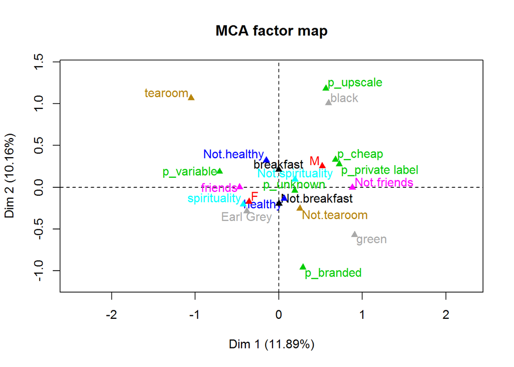

```r
# visualize MCA, individual points are invisible showing only variables.
plot(mca, invisible=c("ind"),  habillage="quali")
```

Nevertheless, we can make some simple interpretations from our data.

Regarding dimension 1 and 2, it’s hard to see clearly separated groups out from the centre. At the centre we can see from the picture that men drink cheap and private label tea and women drink with friends and accosiate tea with health and spirituality.

Also healthy and not.breakfast seem to be the closest groups to each other, but at the same time almost at the zero point between dimensions, showing not great variance between observations. Maybe Those who skip breakfast think tea is so healthy, they don’t even need one.

Somehow black tea -users are related to high prices of tea, although it is most often not the most expencive sort of tea on the markets (at least in Finland).

*MCA graph 2*

```r
res.mca=MCA(my_tea1)
```

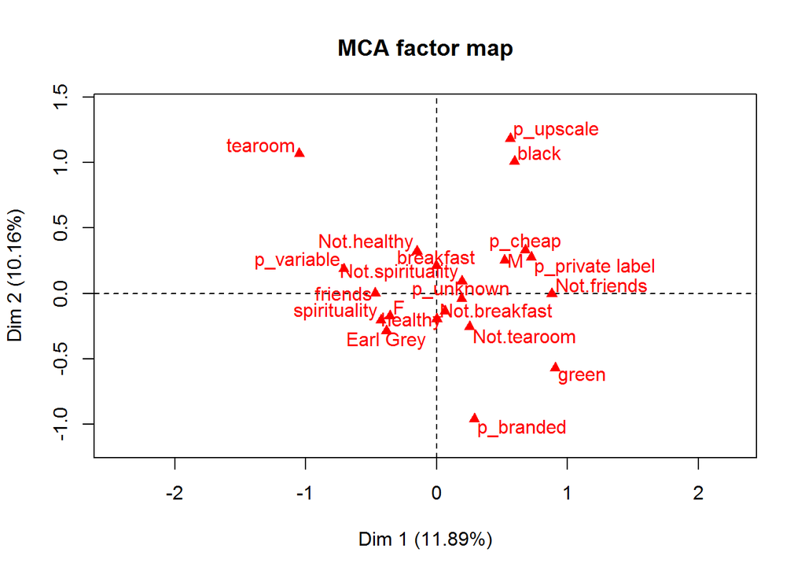

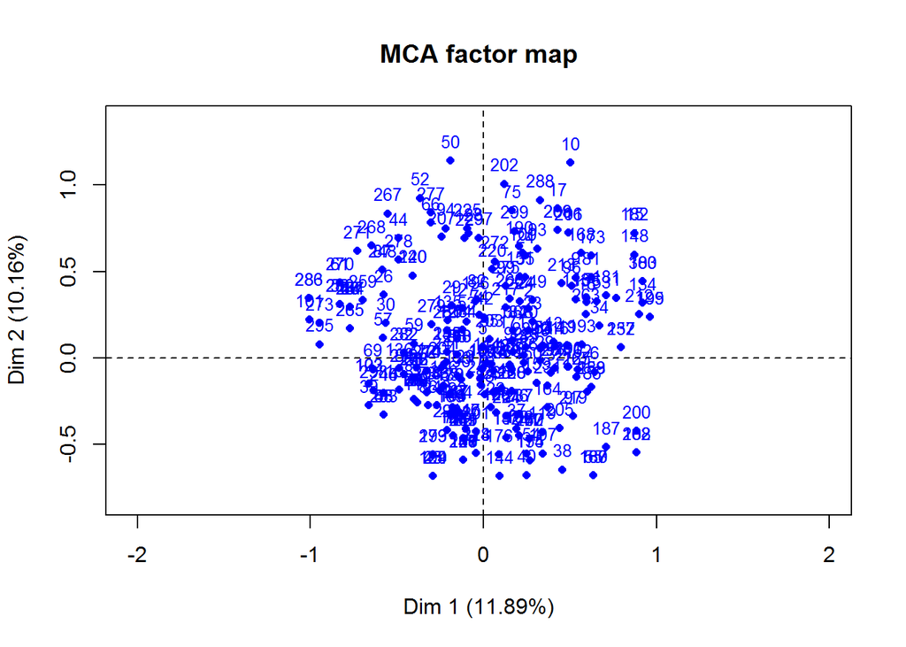

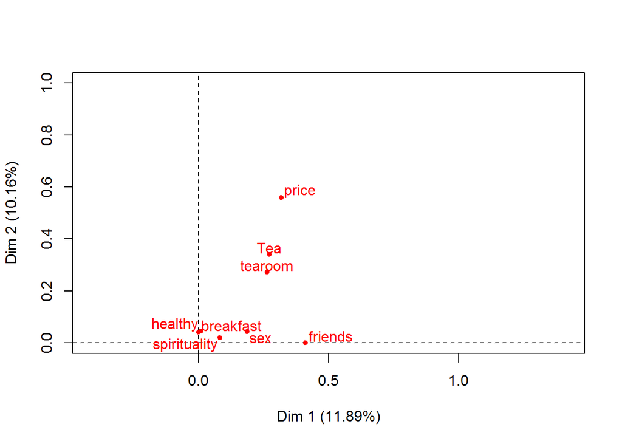

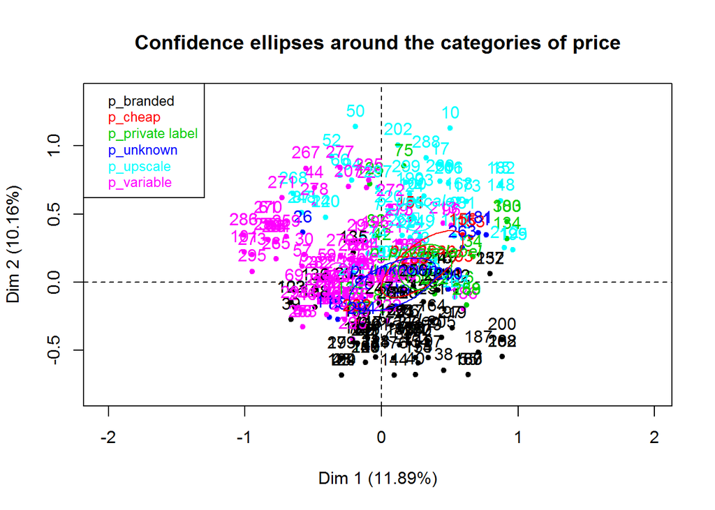

```r
plotellipses(res.mca,keepvar=3)
```

With our additional graph 2 and its third plot we see that price, tea and tearoom most strongly correlate to dimension 2 and friends to dimension 1. This we can see also from the different categories showing in the first MCA graph: Drinking tea in tearooms, higher prices and black tea are those which are most positively connected to dimension 2 and most negatively correlated to dimension 2 is branded tea. Green tea and not drinking with firends are most positively correlated to dimension 1 and drinking in tearoom and price in general are negatively correlated to dimension 1.

Groups that are close and show highest correlation to dimensions are to be considered the most influential ones. Thus, although interesting, the separation between males and females is not as trustworthy than linking high prices with black tea.